# IMDB Project

## Setup

The goal of this project is to research which variables possibly influence the total revenue streams that a released movie generates by performing a multiple regression. For this purpose, data belonging to around 5000 movies from the Internet Movie Database (IMDB) has been used. This data has been retrieved from [Kaggle](https://www.kaggle.com/carolzhangdc/imdb-5000-movie-dataset).

This project is of a more exploratory nature, which means that we are looking for possible connections. As such, it does not contain a strong justification for the included variables and for the analysis methods. Interpret the findings with this information in mind.

First, let’s look at the available data. We start by importing the necessary libraries and by reading the csv file.

```r
library(dplyr)
library(tidyr)

movies <- read.csv(file="movie_metadata.csv")
```

Let’s look at the columns included in this dataset:

```r
str(movies)
```

```
'data.frame':   5043 obs. of  28 variables:
 $ color                    : chr  "Color" "Color" "Color" "Color" ...
 $ director_name            : chr  "James Cameron" "Gore Verbinski" "Sam Mendes" "Christopher Nolan" ...
 $ num_critic_for_reviews   : int  723 302 602 813 NA 462 392 324 635 375 ...
 $ duration                 : int  178 169 148 164 NA 132 156 100 141 153 ...
 $ director_facebook_likes  : int  0 563 0 22000 131 475 0 15 0 282 ...
 $ actor_3_facebook_likes   : int  855 1000 161 23000 NA 530 4000 284 19000 10000 ...
 $ actor_2_name             : chr  "Joel David Moore" "Orlando Bloom" "Rory Kinnear" "Christian Bale" ...
 $ actor_1_facebook_likes   : int  1000 40000 11000 27000 131 640 24000 799 26000 25000 ...
 $ gross                    : int  760505847 309404152 200074175 448130642 NA 73058679 336530303 200807262 458991599 301956980 ...
 $ genres                   : chr  "Action|Adventure|Fantasy|Sci-Fi" "Action|Adventure|Fantasy" "Action|Adventure|Thriller" "Action|Thriller" ...
 $ actor_1_name             : chr  "CCH Pounder" "Johnny Depp" "Christoph Waltz" "Tom Hardy" ...
 $ movie_title              : chr  "AvatarÂ " "Pirates of the Caribbean: At World's EndÂ " "SpectreÂ " "The Dark Knight RisesÂ " ...
 $ num_voted_users          : int  886204 471220 275868 1144337 8 212204 383056 294810 462669 321795 ...
 $ cast_total_facebook_likes: int  4834 48350 11700 106759 143 1873 46055 2036 92000 58753 ...
 $ actor_3_name             : chr  "Wes Studi" "Jack Davenport" "Stephanie Sigman" "Joseph Gordon-Levitt" ...
 $ facenumber_in_poster     : int  0 0 1 0 0 1 0 1 4 3 ...
 $ plot_keywords            : chr  "avatar|future|marine|native|paraplegic" "goddess|marriage ceremony|marriage proposal|pirate|singapore" "bomb|espionage|sequel|spy|terrorist" "deception|imprisonment|lawlessness|police officer|terrorist plot" ...
 $ movie_imdb_link          : chr  "http://www.imdb.com/title/tt0499549/?ref_=fn_tt_tt_1" "http://www.imdb.com/title/tt0449088/?ref_=fn_tt_tt_1" "http://www.imdb.com/title/tt2379713/?ref_=fn_tt_tt_1" "http://www.imdb.com/title/tt1345836/?ref_=fn_tt_tt_1" ...
 $ num_user_for_reviews     : int  3054 1238 994 2701 NA 738 1902 387 1117 973 ...
 $ language                 : chr  "English" "English" "English" "English" ...
 $ country                  : chr  "USA" "USA" "UK" "USA" ...
 $ content_rating           : chr  "PG-13" "PG-13" "PG-13" "PG-13" ...
 $ budget                   : num  2.37e+08 3.00e+08 2.45e+08 2.50e+08 NA ...
 $ title_year               : int  2009 2007 2015 2012 NA 2012 2007 2010 2015 2009 ...
 $ actor_2_facebook_likes   : int  936 5000 393 23000 12 632 11000 553 21000 11000 ...
 $ imdb_score               : num  7.9 7.1 6.8 8.5 7.1 6.6 6.2 7.8 7.5 7.5 ...
 $ aspect_ratio             : num  1.78 2.35 2.35 2.35 NA 2.35 2.35 1.85 2.35 2.35 ...
 $ movie_facebook_likes     : int  33000 0 85000 164000 0 24000 0 29000 118000 10000 ...
```

These columns correspond to the variables that we could use for our analysis. Some of these variables will correlate with the total revenue that movies generate and others will not. In this project, potentially relevant or interesting variables will be handpicked. The variables that we choose will need a plausible connection to total revenue, as well as a sufficient degree of measurability. This means that variables of a categorical or nominal nature (e.g. ‘yes/no’, ‘A/B/C’, ‘0/1’) will be excluded.

The result of this handpicking is as follows:

**Dependent variable:**

- gross (total revenue stream generated by movie in USD)

**Independent variables:**

- duration (total runtime of the movie in minutes)
- budget (total budget of the movie in US dollars)
- num_critic_for_reviews (number of reviews by critics)
- director_facebook_likes (total number of movie director Facebook likes)
- cast_total_facebook_likes (total number of Facebook likes of the entire cast)

As you can see, all of these independent variables are of a numerical nature, meaning they can be measured. Also, all of them, except num_critic_for_reviews, exist before the release of the movie in question. Other variables, like imdb_score (IMDB score), num_voted_users (total number of IMDB users that voted) and movie_facebook_likes (total amount of Facebook likes for the movie) exist as a result of the movie’s release. Because the total revenue is an indicator of the popularity of a movie, it is plausible that the dependent variable gross could have an effect on these variables, creating a kind of feedback loop. We want to make sure that our independent variables remain independent, which is why variables such as these have been excluded.

## Data cleaning

In this section, we “wrangle” the data into a shape that is suitable for the analysis. This section contains filtering by country, variable selection, missing value, duplicate row and outlier removal and data type correction. After every action that modifies the dataset, one of the following two lines of code will be used to display up to date information about the data:

```
summary(movies)
str(movies)
```

### Filtering by country

We want the gross and budget variables to be in US dollars. Currently, (a number of) movies that are produced outside the USA have their values in the gross and budget variables expressed in a local currency. Currency conversion rates being what they are, this can quickly lead to wildly inaccurate analysis results, which is why we filter out all movies that are produced outside the US:

```r
movies <- subset(movies, country == "USA")
str(movies)
```

```
'data.frame':   3807 obs. of  28 variables:
 $ color                    : chr  "Color" "Color" "Color" "Color" ...
 $ director_name            : chr  "James Cameron" "Gore Verbinski" "Christopher Nolan" "Andrew Stanton" ...
 $ num_critic_for_reviews   : int  723 302 813 462 392 324 635 673 434 313 ...
 $ duration                 : int  178 169 164 132 156 100 141 183 169 151 ...
 $ director_facebook_likes  : int  0 563 22000 475 0 15 0 0 0 563 ...
 $ actor_3_facebook_likes   : int  855 1000 23000 530 4000 284 19000 2000 903 1000 ...
 $ actor_2_name             : chr  "Joel David Moore" "Orlando Bloom" "Christian Bale" "Samantha Morton" ...
 $ actor_1_facebook_likes   : int  1000 40000 27000 640 24000 799 26000 15000 18000 40000 ...
 $ gross                    : int  760505847 309404152 448130642 73058679 336530303 200807262 458991599 330249062 200069408 423032628 ...
 $ genres                   : chr  "Action|Adventure|Fantasy|Sci-Fi" "Action|Adventure|Fantasy" "Action|Thriller" "Action|Adventure|Sci-Fi" ...
 $ actor_1_name             : chr  "CCH Pounder" "Johnny Depp" "Tom Hardy" "Daryl Sabara" ...
 $ movie_title              : chr  "AvatarÂ " "Pirates of the Caribbean: At World's EndÂ " "The Dark Knight RisesÂ " "John CarterÂ " ...
 $ num_voted_users          : int  886204 471220 1144337 212204 383056 294810 462669 371639 240396 522040 ...
 $ cast_total_facebook_likes: int  4834 48350 106759 1873 46055 2036 92000 24450 29991 48486 ...
 $ actor_3_name             : chr  "Wes Studi" "Jack Davenport" "Joseph Gordon-Levitt" "Polly Walker" ...
 $ facenumber_in_poster     : int  0 0 0 1 0 1 4 0 0 2 ...
 $ plot_keywords            : chr  "avatar|future|marine|native|paraplegic" "goddess|marriage ceremony|marriage proposal|pirate|singapore" "deception|imprisonment|lawlessness|police officer|terrorist plot" "alien|american civil war|male nipple|mars|princess" ...
 $ movie_imdb_link          : chr  "http://www.imdb.com/title/tt0499549/?ref_=fn_tt_tt_1" "http://www.imdb.com/title/tt0449088/?ref_=fn_tt_tt_1" "http://www.imdb.com/title/tt1345836/?ref_=fn_tt_tt_1" "http://www.imdb.com/title/tt0401729/?ref_=fn_tt_tt_1" ...
 $ num_user_for_reviews     : int  3054 1238 2701 738 1902 387 1117 3018 2367 1832 ...
 $ language                 : chr  "English" "English" "English" "English" ...
 $ country                  : chr  "USA" "USA" "USA" "USA" ...
 $ content_rating           : chr  "PG-13" "PG-13" "PG-13" "PG-13" ...
 $ budget                   : num  2.37e+08 3.00e+08 2.50e+08 2.64e+08 2.58e+08 ...
 $ title_year               : int  2009 2007 2012 2012 2007 2010 2015 2016 2006 2006 ...
 $ actor_2_facebook_likes   : int  936 5000 23000 632 11000 553 21000 4000 10000 5000 ...
 $ imdb_score               : num  7.9 7.1 8.5 6.6 6.2 7.8 7.5 6.9 6.1 7.3 ...
 $ aspect_ratio             : num  1.78 2.35 2.35 2.35 2.35 1.85 2.35 2.35 2.35 2.35 ...
 $ movie_facebook_likes     : int  33000 0 164000 24000 0 29000 118000 197000 0 5000 ...
```

### Variable selection

Let’s modify the dataset to only contain the columns chosen for the analysis:

```r
movies <- movies[c("movie_title", "gross", "duration", "budget", "num_critic_for_reviews",
                   "director_facebook_likes", "cast_total_facebook_likes")]
summary(movies)
```

```
 movie_title            gross              duration         budget          num_critic_for_reviews director_facebook_likes cast_total_facebook_likes
 Length:3807        Min.   :      703   Min.   :  7.0   Min.   :      218   Min.   :  1.0          Min.   :    0.0         Min.   :     0
 Class :character   1st Qu.: 10110274   1st Qu.: 93.0   1st Qu.:  6500000   1st Qu.: 52.0          1st Qu.:    8.0         1st Qu.:  1808
 Mode  :character   Median : 32178777   Median :103.0   Median : 20000000   Median :113.0          Median :   52.0         Median :  3681
                    Mean   : 55214607   Mean   :106.4   Mean   : 35755986   Mean   :143.6          Mean   :  823.1         Mean   : 10891
                    3rd Qu.: 72147000   3rd Qu.:117.0   3rd Qu.: 50000000   3rd Qu.:198.0          3rd Qu.:  212.0         3rd Qu.: 14998
                    Max.   :760505847   Max.   :330.0   Max.   :300000000   Max.   :813.0          Max.   :23000.0         Max.   :656730
                    NA's   :572         NA's   :6       NA's   :298         NA's   :39             NA's   :74
```

### Missing values

```r
movies <- drop_na(movies)
str(movies)
```

```
'data.frame':   3073 obs. of  7 variables:
 $ movie_title              : chr  "AvatarÂ " "Pirates of the Caribbean: At World's EndÂ " "The Dark Knight RisesÂ " "John CarterÂ " ...
 $ gross                    : int  760505847 309404152 448130642 73058679 336530303 200807262 458991599 330249062 200069408 423032628 ...
 $ duration                 : int  178 169 164 132 156 100 141 183 169 151 ...
 $ budget                   : num  2.37e+08 3.00e+08 2.50e+08 2.64e+08 2.58e+08 ...
 $ num_critic_for_reviews   : int  723 302 813 462 392 324 635 673 434 313 ...
 $ director_facebook_likes  : int  0 563 22000 475 0 15 0 0 0 563 ...
 $ cast_total_facebook_likes: int  4834 48350 106759 1873 46055 2036 92000 24450 29991 48486 ...
```

As you can see, after cleaning we are left with a dataset containing 3073 rows. We can be confident that none of these rows contain any missing values.

### Duplicate removal

Duplicates are exactly matching rows that appear multiple times in the dataset. Too many duplicates will skew the analysis results. Luckily, these are easily removed:

```r
movies <- distinct(movies)
str(movies)
```

```
'data.frame':   3006 obs. of  7 variables:
 $ movie_title              : chr  "AvatarÂ " "Pirates of the Caribbean: At World's EndÂ " "The Dark Knight RisesÂ " "John CarterÂ " ...
 $ gross                    : int  760505847 309404152 448130642 73058679 336530303 200807262 458991599 330249062 200069408 423032628 ...
 $ duration                 : int  178 169 164 132 156 100 141 183 169 151 ...
 $ budget                   : num  2.37e+08 3.00e+08 2.50e+08 2.64e+08 2.58e+08 ...
 $ num_critic_for_reviews   : int  723 302 813 462 392 324 635 673 434 313 ...
 $ director_facebook_likes  : int  0 563 22000 475 0 15 0 0 0 563 ...
 $ cast_total_facebook_likes: int  4834 48350 106759 1873 46055 2036 92000 24450 29991 48486 ...
```

The number of rows has gone down from 3073 to 3006, meaning that 67 duplicate rows have been removed.

### Data type

To increase the readability of the data, we need to look at data types next. All of the columns containing numerical values actually only consist integers. This can be confirmed using the following code:

```r
for (col in colnames(movies)[2:7]) {
  cat(paste(col, "is integer: "))
  cat(paste(all(floor(movies[col]) == movies[col]), end="\n"))
}
```

```
gross is integer: TRUE
duration is integer: TRUE
budget is integer: TRUE
num_critic_for_reviews is integer: TRUE
director_facebook_likes is integer: TRUE
cast_total_facebook_likes is integer: TRUE
```

After confirming that we are dealing with integers, the column “budget” can be recast to match the values:

```r
movies$budget <- as.integer(movies$budget)
str(movies)
```

```
'data.frame':   3006 obs. of  7 variables:
 $ movie_title              : chr  "AvatarÂ " "Pirates of the Caribbean: At World's EndÂ " "The Dark Knight RisesÂ " "John CarterÂ " ...
 $ gross                    : int  760505847 309404152 448130642 73058679 336530303 200807262 458991599 330249062 200069408 423032628 ...
 $ duration                 : int  178 169 164 132 156 100 141 183 169 151 ...
 $ budget                   : int  237000000 300000000 250000000 263700000 258000000 260000000 250000000 250000000 209000000 225000000 ...
 $ num_critic_for_reviews   : int  723 302 813 462 392 324 635 673 434 313 ...
 $ director_facebook_likes  : int  0 563 22000 475 0 15 0 0 0 563 ...
 $ cast_total_facebook_likes: int  4834 48350 106759 1873 46055 2036 92000 24450 29991 48486 ...
```

### Outliers

The move industry is a competitive business and as such may be subject to something similar to the [Pareto distribution](https://en.wikipedia.org/wiki/Pareto_distribution). Some movies may see exceptionally high values in certain variables. These high values are then outliers that may skew the analysis results. Outliers must be detected and removed.

A good way to understand data is to visually represent it. The histograms below show how the variables in the dataset are distributed. The height of the bars represents the count of movies in a certain bin of the histogram.

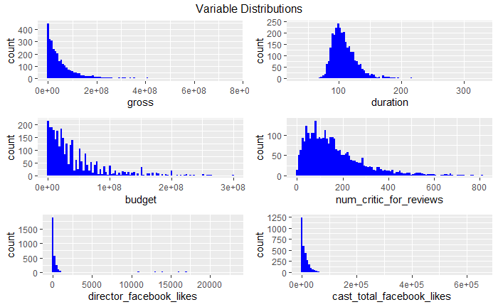

```r
library(ggplot2)
library(gridExtra)

plot1 <- ggplot(movies, aes(x=gross))  + geom_histogram(bins=100, fill="blue")
plot2 <- ggplot(movies, aes(x=duration)) + geom_histogram(bins=100, fill="blue")
plot3 <- ggplot(movies, aes(x=budget)) + geom_histogram(bins=100, fill="blue")
plot4 <- ggplot(movies, aes(x=num_critic_for_reviews)) + geom_histogram(bins=100, fill="blue")
plot5 <- ggplot(movies, aes(x=director_facebook_likes)) + geom_histogram(bins=100, fill="blue")
plot6 <- ggplot(movies, aes(x=cast_total_facebook_likes)) + geom_histogram(bins=100, fill="blue")
grid.arrange(plot1, plot2, plot3, plot4, plot5, plot6, ncol = 2, top = "Variable Distributions")
```

It is immediately obvious that most of these variables are concentrated on the left side of their respective graphs. This is an indication that these variables are dealing with massive outliers that are barely visible in these histograms. The variables budget, director_facebook_likes and cast_total_facebook seem most affected by this, with the vast majority of counts on a very small section of the x-axis, and a vanishingly small amount of counts on the remainder of the x-axis.

The risk exists that these outliers will skew the results of the final analysis. Because of this, a new version of the dataset will be created where the most extreme outliers have been removed. We do this by calculating the z-score of every value for every variable. Values with a z-score of 3 and higher will be removed from the dataset.

```r
z <- as.data.frame(scale(movies[2:7]))
z$movie_title <- movies$movie_title

z_delete <- subset(z, gross >= 3 | duration >= 3 | budget >= 3 | num_critic_for_reviews >= 3 | director_facebook_likes >= 3 | cast_total_facebook_likes >= 3)
movies <- filter(movies, !movie_title %in% z_delete$movie_title)

str(movies)
```

```
'data.frame':   2672 obs. of  7 variables:
 $ movie_title              : chr  "Rush Hour 3Â " "The Mummy: Tomb of the Dragon EmperorÂ " "Shrek Forever AfterÂ " "Big Hero 6Â " ...
 $ gross                    : int  140080850 102176165 238371987 222487711 189412677 665426 102315545 217387997 144512310 146405371 ...
 $ duration                 : int  91 112 93 102 101 100 120 98 106 132 ...
 $ budget                   : int  140000000 145000000 165000000 165000000 165000000 165000000 165000000 165000000 38000000 160000000 ...
 $ num_critic_for_reviews   : int  162 264 226 384 377 188 286 288 187 500 ...
 $ director_facebook_likes  : int  420 357 31 38 66 0 776 255 357 905 ...
 $ cast_total_facebook_likes: int  1125 9131 4628 2963 4451 16264 3233 20453 45327 50983 ...
```

As you can see, we are left with 2672 rows. Now let’s take a look at the histograms from earlier, but with outliers removed:

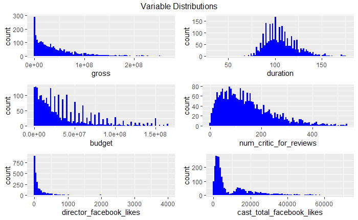

```r
plot7 <- ggplot(movies, aes(x=gross))  + geom_histogram(bins=100, fill="blue")
plot8 <- ggplot(movies, aes(x=duration)) + geom_histogram(bins=100, fill="blue")
plot9 <- ggplot(movies, aes(x=budget)) + geom_histogram(bins=100, fill="blue")
plot10 <- ggplot(movies, aes(x=num_critic_for_reviews)) + geom_histogram(bins=100, fill="blue")
plot11 <- ggplot(movies, aes(x=director_facebook_likes)) + geom_histogram(bins=100, fill="blue")
plot12 <- ggplot(movies, aes(x=cast_total_facebook_likes)) + geom_histogram(bins=100, fill="blue")
grid.arrange(plot7, plot8, plot9, plot10, plot11, plot12, ncol = 2, top = "Variable Distributions")
```

The overall shape of the histograms is similar to before, but removing the more extreme outliers has improved the visibility and will lead to more accurate analysis results.

Our dataset is now prepared for analysis. To get an impression of what the final dataset looks like, here is a display of the 15 highest grossing movies in the dataset.

```r
head(movies[order(-movies$gross),], n=15L)
```

|  | movie_title | gross | duration | budget | num_critic_for_reviews | director_facebook_likes | cast_total_facebook_likes |
| --- | --- | --- | --- | --- | --- | --- | --- |
| 579 | ShrekÂ | 267652016 | 90 | 60000000 | 212 | 80 | 275 |
| 172 | The IncrediblesÂ | 261437578 | 115 | 92000000 | 283 | 663 | 1901 |
| 79 | How the Grinch Stole ChristmasÂ | 260031035 | 110 | 123000000 | 175 | 2000 | 4146 |
| 16 | I Am LegendÂ | 256386216 | 104 | 150000000 | 323 | 508 | 13076 |
| 915 | The Blind SideÂ | 255950375 | 129 | 29000000 | 261 | 102 | 3389 |
| 240 | The Hangover Part IIÂ | 254455986 | 102 | 80000000 | 383 | 480 | 16143 |
| 385 | Despicable MeÂ | 251501645 | 87 | 69000000 | 304 | 275 | 11608 |
| 101 | Night at the MuseumÂ | 250863268 | 108 | 110000000 | 179 | 189 | 55486 |
| 174 | Men in BlackÂ | 250147615 | 98 | 90000000 | 175 | 188 | 12998 |
| 175 | Toy Story 2Â | 245823397 | 82 | 90000000 | 191 | 487 | 21275 |

[output cut: 5 more lines]

## Analysis

**Descriptive analysis**

Before running the numbers, descriptive and visual statistics will be shown. This helps the reader to get an understanding of the data. The next table displays some of the most commonly used descriptive statistics of the variables in the dataset (rounded for readability). These statistics are the mean, minimum and maximum values and the lower quartile, median and upper quartile.

```r
summary(movies)
```

```
 movie_title            gross              duration         budget          num_critic_for_reviews director_facebook_likes cast_total_facebook_likes
 Length:2672        Min.   :      703   Min.   : 34.0   Min.   :      218   Min.   :  1.0          Min.   :   0.0          Min.   :    0
 Class :character   1st Qu.:  9662830   1st Qu.: 94.0   1st Qu.:  9375000   1st Qu.: 66.0          1st Qu.:  10.0          1st Qu.: 2054
 Mode  :character   Median : 30507411   Median :103.5   Median : 24000000   Median :123.0          Median :  52.0          Median : 3985
                    Mean   : 45683894   Mean   :106.1   Mean   : 33609690   Mean   :144.4          Mean   : 152.2          Mean   :10120
                    3rd Qu.: 64580616   3rd Qu.:116.0   3rd Qu.: 48250000   3rd Qu.:198.0          3rd Qu.: 179.0          3rd Qu.:15270
                    Max.   :267652016   Max.   :176.0   Max.   :165000000   Max.   :535.0          Max.   :4000.0          Max.   :71973
```

Here are the standard deviations for each variable:

```r
print("Standard Deviation")
```

```
[1] "Standard Deviation"
```

```r
apply(movies[2:7], 2, sd)
```

```
                    gross                  duration                    budget    num_critic_for_reviews   director_facebook_likes cast_total_facebook_likes
             4.909740e+07              1.677306e+01              3.310704e+07              1.021114e+02              2.856708e+02              1.218209e+04
```

**Visual analysis**

Scatter plots are a useful tool for visualizing the relationship between variables. In this case, the scatter plots display the relationship between each variable in the dataset and the dependent variable gross. The first scatter plot (top left) can be ignored.

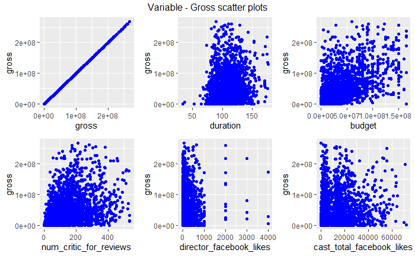

```r
plot13 <- ggplot(movies, aes(x=gross, y=gross)) + geom_point(color="blue")
plot14 <- ggplot(movies, aes(x=duration, y=gross)) + geom_point(color="blue")
plot15 <- ggplot(movies, aes(x=budget, y=gross)) + geom_point(color="blue")
plot16 <- ggplot(movies, aes(x=num_critic_for_reviews, y=gross)) + geom_point(color="blue")
plot17 <- ggplot(movies, aes(x=director_facebook_likes, y=gross)) + geom_point(color="blue")
plot18 <- ggplot(movies, aes(x=cast_total_facebook_likes, y=gross)) + geom_point(color="blue")
grid.arrange(plot13, plot14, plot15, plot16, plot17, plot18, ncol = 3, top = "Variable - Gross scatter plots")
```

**Statistical analysis**

In this section we find out whether the data can be used to find statistically significant results, and if so, what these results are and how they fit the insights derived from the scatter plots. We make use of multiple linear regression for the statistical analysis.

The first step is to create and fit a statistical model.

```r
model <- lm(gross ~ duration + budget + num_critic_for_reviews + director_facebook_likes + cast_total_facebook_likes, data=movies)
```

**Multicollinearity testing**

Multicollinearity is a term for a situation where multiple independent variables in a statistical model not only influence the dependent variable, but also each other. Too much multicollinearity will lead to unreliable analysis results.

We can test for multicollinearity by calculate the Variance Inflation Factor (VIF) for each independent variable. VIF values under 3 are ideal, VIF values over 5 indicate some multicollinearity and VIF values over 10 indicate severely problematic levels of multicollinearity.

```r
library(car)
vif(model)
```

```
                 duration                    budget    num_critic_for_reviews   director_facebook_likes cast_total_facebook_likes
                 1.125174                  1.202859                  1.220346                  1.062023                  1.133469
```

The calculated VIF values are small enough that we can reliably proceed with the statistical analysis; no variables need to be removed.

Now, let’s view the results of the statistical model:

```r
summary(model)
```

```
Call:
lm(formula = gross ~ duration + budget + num_critic_for_reviews +
    director_facebook_likes + cast_total_facebook_likes, data = movies)

Residuals:
       Min         1Q     Median         3Q        Max
-144952929  -21824452   -8777061   12734387  218890063

Coefficients:
                            Estimate Std. Error t value Pr(>|t|)
(Intercept)               -7.349e+06  4.879e+06  -1.506  0.13216
duration                   1.404e+05  4.767e+04   2.946  0.00324 **
budget                     7.477e-01  2.497e-02  29.945  < 2e-16 ***
num_critic_for_reviews     7.336e+04  8.154e+03   8.997  < 2e-16 ***
director_facebook_likes    8.651e+03  2.719e+03   3.182  0.00148 **
cast_total_facebook_likes  1.081e+02  6.587e+01   1.641  0.10099
---
Signif. codes:  0 ‘***’ 0.001 ‘**’ 0.01 ‘*’ 0.05 ‘.’ 0.1 ‘ ’ 1

Residual standard error: 38950000 on 2666 degrees of freedom
Multiple R-squared:  0.3717,    Adjusted R-squared:  0.3705
F-statistic: 315.4 on 5 and 2666 DF,  p-value: < 2.2e-16
```

**Interpretation**

The regression results summary gives us a lot of information, not all of which is relevant. The most important results will be listed here:

- The adjusted R-squared value of 0.3705 means that 37.05% of the total variance of the dependent variable gross is explained by the independent variables included in the model. 62.95% of the total variance is not explained.
- The column “Estimate” shows the regression coefficients for each variable. As you can see, all coefficients are positive, indicating a positive relationship between the independent variable in question and the dependent variable gross.
- The column “Pr(>|t|)” shows the p-values, which indicate how statistically significant each regression coefficient is. Working with a treshold of α = 0.05, the following positive regression coefficients are statistically significant:
  - duration
  - budget: strong positive coefficient
  - num_critic_for_reviews
  - director_facebook_likes

**Export**

The analysis is concluded. We can now export the final dataset as a csv file to be used with other tools, such as database or visualization software.

```r
write.csv2(movies, "movies_output.csv", row.names=FALSE)
```